# Hackathon Machine Learning Report

Maxime BOURGEOIS | Julien FINK

2020-12-17 19:13:40

# Import the Dataset

```r
my_data_train <- read.csv('data.csv')
my_data_test <- read.csv('test.csv')
```

# Data Exploration (analyse correlation)

```r
str(my_data_train)
```

```
## 'data.frame':    9000 obs. of  13 variables:
##  $ tau1: num  9.304 8.972 0.716 3.134 6.999 ...
##  $ tau2: num  4.9 8.85 7.67 7.61 9.11 ...
##  $ tau3: num  3.05 3.05 4.49 4.94 3.78 ...
##  $ tau4: num  1.37 1.21 2.34 9.86 4.27 ...
##  $ p1  : num  5.07 3.41 3.96 3.53 4.43 ...
##  $ p2  : num  -1.94 -1.21 -1.03 -1.13 -1.86 ...
##  $ p3  : num  -1.87 -1.28 -1.94 -1.85 -0.67 ...
##  $ p4  : num  -1.255 -0.92 -0.997 -0.554 -1.902 ...
##  $ g1  : num  0.413 0.163 0.446 0.797 0.262 ...
##  $ g2  : num  0.8624 0.7667 0.9767 0.4554 0.0779 ...
##  $ g3  : num  0.562 0.839 0.929 0.657 0.543 ...
##  $ g4  : num  0.782 0.11 0.363 0.821 0.47 ...
##  $ stab: Factor w/ 2 levels "stable","unstable": 1 2 2 2 1 2 2 1 1 2 ...
```

```r
str(my_data_test)
```

```
## 'data.frame':    1000 obs. of  12 variables:
##  $ tau1: num  4.26 7.93 9.92 2.36 7.4 ...
##  $ tau2: num  7.02 8.51 9.46 9.95 2.51 ...
##  $ tau3: num  8.2 4.93 3.13 9.99 1.54 ...
##  $ tau4: num  9.68 3.06 9.74 3.58 4.56 ...
##  $ p1  : num  4.86 3.12 3.56 3.95 3.55 ...
##  $ p2  : num  -1.945 -1.046 -0.901 -1.937 -1.421 ...
##  $ p3  : num  -1.157 -1.074 -1.163 -0.892 -0.977 ...
##  $ p4  : num  -1.761 -0.995 -1.496 -1.118 -1.151 ...
##  $ g1  : num  0.9207 0.6246 0.5704 0.1532 0.0944 ...
##  $ g2  : num  0.103 0.193 0.152 0.106 0.054 ...
##  $ g3  : num  0.0598 0.4209 0.316 0.5421 0.362 ...
##  $ g4  : num  0.849 0.981 0.55 0.677 0.822 ...
```

```r
head(my_data_train)
```

```
##        tau1     tau2     tau3     tau4       p1         p2         p3
## 1 9.3040972 4.902524 3.047541 1.369357 5.067812 -1.9400584 -1.8727417
## 2 8.9717069 8.848428 3.046479 1.214518 3.405158 -1.2074556 -1.2772101
## 3 0.7164148 7.669600 4.486641 2.340563 3.963791 -1.0274733 -1.9389442
## 4 3.1341116 7.608772 4.943759 9.857573 3.525811 -1.1255310 -1.8459749
## 5 6.9992087 9.109247 3.784066 4.267788 4.429669 -1.8571392 -0.6703968
## 6 6.7101664 3.765204 6.929314 8.818562 2.397419 -0.6145896 -1.2088259
##           p4        g1         g2        g3        g4     stab
## 1 -1.2550120 0.4134406 0.86241408 0.5621391 0.7817599   stable
## 2 -0.9204924 0.1630410 0.76668866 0.8394440 0.1098532 unstable
## 3 -0.9973736 0.4462089 0.97674408 0.9293805 0.3627178 unstable
## 4 -0.5543050 0.7971095 0.45544995 0.6569467 0.8209235 unstable
## 5 -1.9021328 0.2617929 0.07792967 0.5428839 0.4699310   stable
## 6 -0.5740038 0.1778896 0.39797658 0.4020460 0.3766303 unstable
```

```r
summary(my_data_train)
```

```
##       tau1             tau2              tau3             tau4
##  Min.   :0.5008   Min.   : 0.5001   Min.   :0.5008   Min.   :0.5005
##  1st Qu.:2.9059   1st Qu.: 2.8771   1st Qu.:2.8612   1st Qu.:2.8969
##  Median :5.2791   Median : 5.2618   Median :5.2803   Median :5.2710
##  Mean   :5.2657   Mean   : 5.2546   Mean   :5.2571   Mean   :5.2607
##  3rd Qu.:7.6239   3rd Qu.: 7.6284   3rd Qu.:7.6311   3rd Qu.:7.6489
##  Max.   :9.9995   Max.   : 9.9998   Max.   :9.9994   Max.   :9.9994
##        p1              p2                p3                p4
##  Min.   :1.583   Min.   :-1.9999   Min.   :-1.9997   Min.   :-1.9999
##  1st Qu.:3.221   1st Qu.:-1.6275   1st Qu.:-1.6275   1st Qu.:-1.6272
##  Median :3.755   Median :-1.2523   Median :-1.2547   Median :-1.2541
##  Mean   :3.755   Mean   :-1.2502   Mean   :-1.2521   Mean   :-1.2526
##  3rd Qu.:4.289   3rd Qu.:-0.8708   3rd Qu.:-0.8783   3rd Qu.:-0.8778
##  Max.   :5.827   Max.   :-0.5001   Max.   :-0.5001   Max.   :-0.5000
##        g1                g2                g3                g4
##  Min.   :0.05001   Min.   :0.05005   Min.   :0.05005   Min.   :0.05003
##  1st Qu.:0.28839   1st Qu.:0.28880   1st Qu.:0.28600   1st Qu.:0.28727
##  Median :0.52557   Median :0.52577   Median :0.52298   Median :0.52250
##  Mean   :0.52527   Mean   :0.52550   Mean   :0.52475   Mean   :0.52366
##  3rd Qu.:0.76243   3rd Qu.:0.76089   3rd Qu.:0.76383   3rd Qu.:0.76087
##  Max.   :0.99994   Max.   :0.99994   Max.   :0.99998   Max.   :0.99988
##        stab
##  stable  :3263
##  unstable:5737
##
##
##
##
```

```r
# Correlation
library(corrplot)
corrData = my_data_train
corrData$stab <- NULL

cor(corrData)
```

```
##              tau1         tau2         tau3         tau4            p1
## tau1  1.000000000  0.020179635 -0.004752184 -0.017077434  0.0248479525
## tau2  0.020179635  1.000000000  0.020590827  0.001342856 -0.0081634776
## tau3 -0.004752184  0.020590827  1.000000000  0.005441477  0.0232325852
## tau4 -0.017077434  0.001342856  0.005441477  1.000000000 -0.0023166225
## p1    0.024847952 -0.008163478  0.023232585 -0.002316622  1.0000000000
## p2   -0.011466056  0.012322710 -0.007552980  0.008363499 -0.5721146726
## p3   -0.020781610  0.005749893 -0.012047577  0.007658540 -0.5852410119
## p4   -0.010870398 -0.003933727 -0.020730559 -0.012030345 -0.5777589334
## g1    0.017367908  0.003066747 -0.014703292 -0.005447027 -0.0006577628
## g2    0.015492475  0.011666257  0.008247272  0.004507982  0.0133500569
## g3    0.002046158  0.014927121  0.014273726  0.002818581 -0.0095332462
## g4    0.013245680 -0.011418035 -0.011814835  0.003512658 -0.0181773184
##                p2           p3            p4            g1           g2
## tau1 -0.011466056 -0.020781610 -0.0108703985  0.0173679082  0.015492475
## tau2  0.012322710  0.005749893 -0.0039337273  0.0030667474  0.011666257
## tau3 -0.007552980 -0.012047577 -0.0207305592 -0.0147032923  0.008247272
## tau4  0.008363499  0.007658540 -0.0120303452 -0.0054470268  0.004507982
## p1   -0.572114673 -0.585241012 -0.5777589334 -0.0006577628  0.013350057
## p2    1.000000000  0.001468747 -0.0107114789  0.0226725165 -0.010578279
## p3    0.001468747  1.000000000  0.0145570157 -0.0065896047 -0.015400900
## p4   -0.010711479  0.014557016  1.0000000000 -0.0150087215  0.002830882
## g1    0.022672516 -0.006589605 -0.0150087215  1.0000000000  0.004501046
## g2   -0.010578279 -0.015400900  0.0028308820  0.0045010463  1.000000000
## g3    0.008562891  0.007836010  0.0001304622 -0.0019768423 -0.010974773
## g4    0.025262601 -0.011697962  0.0179443547  0.0083989019 -0.012576301
##                 g3           g4
## tau1  0.0020461579  0.013245680
## tau2  0.0149271209 -0.011418035
## tau3  0.0142737264 -0.011814835
## tau4  0.0028185810  0.003512658
## p1   -0.0095332462 -0.018177318
## p2    0.0085628910  0.025262601
## p3    0.0078360100 -0.011697962
## p4    0.0001304622  0.017944355
## g1   -0.0019768423  0.008398902
## g2   -0.0109747731 -0.012576301
## g3    1.0000000000  0.008284518
## g4    0.0082845179  1.000000000
```

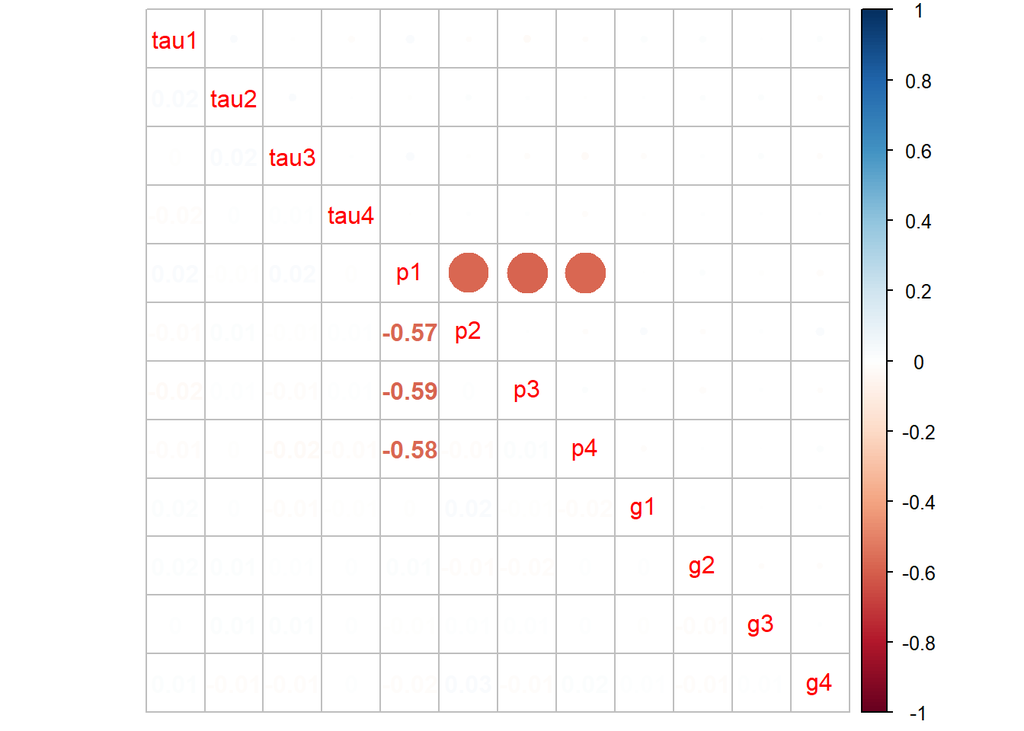

```r
corrplot.mixed(cor(corrData))
```

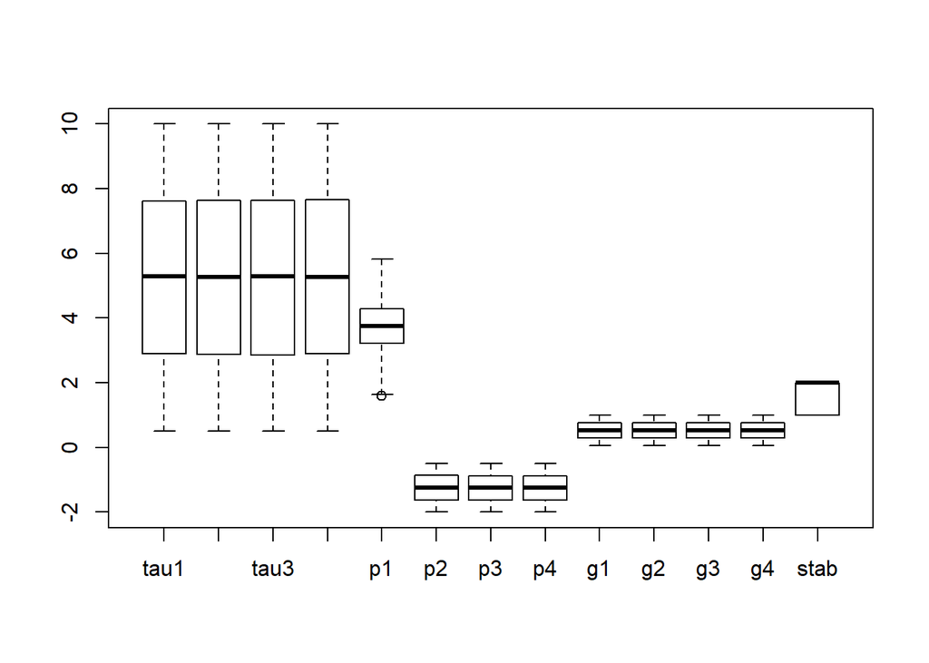

```r
boxplot(my_data_train)
```

We can obberve that values in tau1, tau2, tau3, tau 4 are hight compared to other, that means that we need to Scale data.

We can see that p1 is relativly correlated with p2, p3, p4.

We have to be careful about this.

# Data Cleanup

```r
my_data_train$stab = ifelse(my_data_train$stab=="stable", 1, 0)
```

# Train the Model | Export the Results

# Naive glm

```r
model.glm1 = glm(stab ~ ., family = binomial, data = my_data_train)
summary(model.glm1)
```

```
##
## Call:
## glm(formula = stab ~ ., family = binomial, data = my_data_train)
##
## Deviance Residuals:
##     Min       1Q   Median       3Q      Max
## -2.5044  -0.6060  -0.2186   0.5469   3.0365
##
## Coefficients: (1 not defined because of singularities)
##             Estimate Std. Error z value Pr(>|z|)
## (Intercept) 11.87607    0.30152  39.388   <2e-16 ***
## tau1        -0.31380    0.01197 -26.216   <2e-16 ***
## tau2        -0.32892    0.01208 -27.237   <2e-16 ***
## tau3        -0.31743    0.01203 -26.392   <2e-16 ***
## tau4        -0.33934    0.01218 -27.861   <2e-16 ***
## p1          -0.10132    0.06862  -1.477   0.1398
## p2          -0.11330    0.09695  -1.169   0.2425
## p3          -0.18877    0.09859  -1.915   0.0555 .
## p4                NA         NA      NA       NA
## g1          -2.68263    0.11678 -22.971   <2e-16 ***
## g2          -2.90114    0.11882 -24.417   <2e-16 ***
## g3          -3.14992    0.11978 -26.298   <2e-16 ***
## g4          -2.88778    0.11851 -24.368   <2e-16 ***
## ---
## Signif. codes:  0 '***' 0.001 '**' 0.01 '*' 0.05 '.' 0.1 ' ' 1
##
## (Dispersion parameter for binomial family taken to be 1)
##
##     Null deviance: 11788  on 8999  degrees of freedom
## Residual deviance:  6993  on 8988  degrees of freedom
## AIC: 7017
##
## Number of Fisher Scoring iterations: 6
```

AIC : 7017 - really high, not a good response

Also we have non significant coefficients, we will try next to remove them.

# Backward Selection glm

```r
library(MASS)
stepAIC(model.glm1, direction="backward")
```

```
## Start:  AIC=7016.95
## stab ~ tau1 + tau2 + tau3 + tau4 + p1 + p2 + p3 + p4 + g1 + g2 +
##     g3 + g4
##
##
## Step:  AIC=7016.95
## stab ~ tau1 + tau2 + tau3 + tau4 + p1 + p2 + p3 + g1 + g2 + g3 +
##     g4
##
##        Df Deviance    AIC
## - p2    1   6994.3 7016.3
## <none>      6993.0 7017.0
## - p1    1   6995.1 7017.1
## - p3    1   6996.6 7018.6
## - g1    1   7585.2 7607.2
## - g4    1   7672.6 7694.6
## - g2    1   7675.1 7697.1
## - tau1  1   7795.7 7817.7
## - g3    1   7802.6 7824.6
## - tau3  1   7809.5 7831.5
## - tau2  1   7870.8 7892.8
## - tau4  1   7922.6 7944.6
##
## Step:  AIC=7016.32
## stab ~ tau1 + tau2 + tau3 + tau4 + p1 + p3 + g1 + g2 + g3 + g4
##
##        Df Deviance    AIC
## - p1    1   6995.2 7015.2
## <none>      6994.3 7016.3
## - p3    1   6996.7 7016.7
## - g1    1   7587.6 7607.6
## - g4    1   7674.3 7694.3
## - g2    1   7676.0 7696.0
## - tau1  1   7796.8 7816.8
## - g3    1   7803.6 7823.6
## - tau3  1   7811.2 7831.2
## - tau2  1   7873.3 7893.3
## - tau4  1   7924.4 7944.4
##
## Step:  AIC=7015.17
```

[output cut: 12 more lines]

```
## - tau4  1   7925.7 7943.7
##
## Step:  AIC=7014.68
## stab ~ tau1 + tau2 + tau3 + tau4 + g1 + g2 + g3 + g4
##
##        Df Deviance    AIC
## <none>      6996.7 7014.7
## - g1    1   7589.9 7605.9
## - g4    1   7675.4 7691.4
## - g2    1   7678.1 7694.1
## - tau1  1   7798.0 7814.0
## - g3    1   7805.4 7821.4
## - tau3  1   7813.9 7829.9
## - tau2  1   7875.1 7891.1
## - tau4  1   7927.7 7943.7
```

```
##
## Call:  glm(formula = stab ~ tau1 + tau2 + tau3 + tau4 + g1 + g2 + g3 +
##     g4, family = binomial, data = my_data_train)
##
## Coefficients:
## (Intercept)         tau1         tau2         tau3         tau4           g1
##     11.8670      -0.3133      -0.3289      -0.3173      -0.3395      -2.6841
##          g2           g3           g4
##     -2.8982      -3.1463      -2.8838
##
## Degrees of Freedom: 8999 Total (i.e. Null);  8991 Residual
## Null Deviance:       11790
## Residual Deviance: 6997  AIC: 7015
```

AIC = 7015 better but also very hight

# Interaction Effects glm

```r
model.glm2 = glm(stab ~ .:., family = binomial, data = my_data_train)
summary(model.glm2)
```

```
##
## Call:
## glm(formula = stab ~ .:., family = binomial, data = my_data_train)
##
## Deviance Residuals:
##     Min       1Q   Median       3Q      Max
## -2.8365  -0.2462  -0.0113   0.2087   3.8466
##
## Coefficients: (9 not defined because of singularities)
##               Estimate Std. Error z value Pr(>|z|)
## (Intercept) -2.6533752  2.2641340  -1.172 0.241231
## tau1         1.7094134  0.1449154  11.796  < 2e-16 ***
## tau2         1.7982869  0.1444643  12.448  < 2e-16 ***
## tau3         1.7865961  0.1458648  12.248  < 2e-16 ***
## tau4         1.7733781  0.1454229  12.195  < 2e-16 ***
## p1           0.1379906  1.0203687   0.135 0.892425
## p2          -0.2522147  1.3965652  -0.181 0.856684
## p3          -0.4835989  1.4092492  -0.343 0.731478
## p4                  NA         NA      NA       NA
## g1          -5.1152193  1.3318800  -3.841 0.000123 ***
## g2          -4.9001450  1.3406792  -3.655 0.000257 ***
## g3          -4.9130149  1.3785721  -3.564 0.000365 ***
## g4          -3.6305670  1.3419805  -2.705 0.006823 **
## tau1:tau2   -0.1183537  0.0069439 -17.044  < 2e-16 ***
## tau1:tau3   -0.1223656  0.0069739 -17.546  < 2e-16 ***
## tau1:tau4   -0.1159620  0.0069822 -16.608  < 2e-16 ***
## tau1:p1     -0.0012721  0.0364556  -0.035 0.972163
## tau1:p2      0.0121804  0.0509497   0.239 0.811054
## tau1:p3     -0.0249082  0.0506501  -0.492 0.622882
## tau1:p4             NA         NA      NA       NA
## tau1:g1     -1.3412362  0.0679109 -19.750  < 2e-16 ***
## tau1:g2      0.0537541  0.0618496   0.869 0.384787
## tau1:g3      0.0161887  0.0610557   0.265 0.790897
## tau1:g4      0.0147080  0.0619188   0.238 0.812240
## tau2:tau3   -0.1145665  0.0070244 -16.310  < 2e-16 ***
## tau2:tau4   -0.1247652  0.0070058 -17.809  < 2e-16 ***
## tau2:p1      0.0004169  0.0369240   0.011 0.990992
## tau2:p2      0.0277021  0.0530770   0.522 0.601724
## tau2:p3      0.0590429  0.0530414   1.113 0.265645
## tau2:p4             NA         NA      NA       NA
```

[output cut: 44 more lines]

```
## g1:g3        4.5053087  0.6103284   7.382 1.56e-13 ***
## g1:g4        4.2755734  0.6202051   6.894 5.43e-12 ***
## g2:g3        3.4291247  0.6139016   5.586 2.33e-08 ***
## g2:g4        2.9895102  0.6132665   4.875 1.09e-06 ***
## g3:g4        3.6486060  0.6199671   5.885 3.98e-09 ***
## ---
## Signif. codes:  0 '***' 0.001 '**' 0.01 '*' 0.05 '.' 0.1 ' ' 1
##
## (Dispersion parameter for binomial family taken to be 1)
##
##     Null deviance: 11787.7  on 8999  degrees of freedom
## Residual deviance:  4171.6  on 8930  degrees of freedom
## AIC: 4311.6
##
## Number of Fisher Scoring iterations: 8
```

# glm Model With Interactions

```r
model.glm3 = glm(stab ~ tau1 + tau2 + tau3 + tau4 + p1 + p2 + p3 +
    p4 + g1 + g2 + g3 + g4 + tau1:tau2 + tau1:tau3 + tau1:tau4 +
    tau1:g1 + tau2:tau3 + tau2:tau4 + tau2:p3 + tau2:g2 + tau3:tau4 +
    tau3:g3 + tau4:p1 + tau4:p2 + tau4:g4 + p1:p4 + p3:g4 + g1:g2 +
    g1:g3 + g1:g4 + g2:g3 + g2:g4 + g3:g4,
    family = binomial,
    data = my_data_train)
summary(model.glm3)
```

```
##
## Call:
## glm(formula = stab ~ tau1 + tau2 + tau3 + tau4 + p1 + p2 + p3 +
##     p4 + g1 + g2 + g3 + g4 + tau1:tau2 + tau1:tau3 + tau1:tau4 +
##     tau1:g1 + tau2:tau3 + tau2:tau4 + tau2:p3 + tau2:g2 + tau3:tau4 +
##     tau3:g3 + tau4:p1 + tau4:p2 + tau4:g4 + p1:p4 + p3:g4 + g1:g2 +
##     g1:g3 + g1:g4 + g2:g3 + g2:g4 + g3:g4, family = binomial,
##     data = my_data_train)
##
## Deviance Residuals:
##     Min       1Q   Median       3Q      Max
## -2.8839  -0.2480  -0.0112   0.2131   3.8543
##
## Coefficients: (1 not defined because of singularities)
##              Estimate Std. Error z value Pr(>|z|)
## (Intercept) -4.368292   1.043089  -4.188 2.82e-05 ***
## tau1         1.782558   0.078462  22.719  < 2e-16 ***
## tau2         1.867372   0.088518  21.096  < 2e-16 ***
## tau3         1.804414   0.077909  23.161  < 2e-16 ***
## tau4         1.749399   0.109784  15.935  < 2e-16 ***
## p1           0.967258   0.629020   1.538 0.124116
## p2           0.320045   0.508763   0.629 0.529307
## p3           0.202544   0.541243   0.374 0.708241
## p4                 NA         NA      NA       NA
## g1          -4.827552   0.665075  -7.259 3.91e-13 ***
## g2          -3.914927   0.664614  -5.891 3.85e-09 ***
## g3          -4.394243   0.671639  -6.543 6.05e-11 ***
## g4          -2.796883   0.796924  -3.510 0.000449 ***
## tau1:tau2   -0.120269   0.006587 -18.258  < 2e-16 ***
## tau1:tau3   -0.122773   0.006601 -18.599  < 2e-16 ***
## tau1:tau4   -0.116071   0.006588 -17.618  < 2e-16 ***
## tau1:g1     -1.353518   0.064932 -20.845  < 2e-16 ***
## tau2:tau3   -0.116185   0.006586 -17.641  < 2e-16 ***
## tau2:tau4   -0.125401   0.006584 -19.047  < 2e-16 ***
## tau2:p3      0.055366   0.034421   1.609 0.107725
## tau2:g2     -1.358690   0.065550 -20.727  < 2e-16 ***
## tau3:tau4   -0.117377   0.006657 -17.633  < 2e-16 ***
## tau3:g3     -1.435978   0.066962 -21.445  < 2e-16 ***
## tau4:p1      0.062475   0.024742   2.525 0.011567 *
## tau4:p2      0.125823   0.041906   3.002 0.002678 **
## tau4:g4     -1.474094   0.068162 -21.626  < 2e-16 ***
## p1:p4        0.277819   0.123196   2.255 0.024127 *
## p3:g4        0.627005   0.342933   1.828 0.067496 .
## g1:g2        3.978119   0.562711   7.070 1.55e-12 ***
## g1:g3        4.435856   0.570629   7.774 7.63e-15 ***
## g1:g4        4.098735   0.576156   7.114 1.13e-12 ***
## g2:g3        3.353324   0.574135   5.841 5.20e-09 ***
## g2:g4        2.878760   0.574062   5.015 5.31e-07 ***
## g3:g4        3.446273   0.580829   5.933 2.97e-09 ***
## ---
## Signif. codes:  0 '***' 0.001 '**' 0.01 '*' 0.05 '.' 0.1 ' ' 1
##
## (Dispersion parameter for binomial family taken to be 1)
##
##     Null deviance: 11787.7  on 8999  degrees of freedom
## Residual deviance:  4187.7  on 8967  degrees of freedom
## AIC: 4253.7
##
## Number of Fisher Scoring iterations: 8
```

AIC = 4254

AIC is improved when we add some interactions

This is our best model for glm method.

## Predictions

```r
pred = predict(model.glm3, my_data_test, type="response")
pred.glm_stab = ifelse(pred >= 0.5, "stable", "unstable")
```

## Write csv

```r
to_be_submitted = data.frame(id=rownames(my_data_test), target=pred.glm_stab)
write.csv(to_be_submitted , file = "glmModel.csv", row.names = F)
```

# Random Forest

Let us train other models with decision trees ! Afterwards, we will compare the different results obtained and discuss about them

```r
library(randomForest)
rand_forest_model = randomForest(stab ~ ., data = my_data_train)
```

## Predictions

```r
pred = predict(rand_forest_model, newdata = my_data_test, type ="response")
pred.randf_stab = ifelse(pred >= 0.5, "stable", "unstable")
```

## Write the predicted values to a csv file

```r
to_be_submitted = data.frame(id=rownames(my_data_test), target=pred.randf_stab)
write.csv(to_be_submitted , file = "randForestModel.csv", row.names = F)
```

# Random Forest Improvement

## Improving the ramdom forest previously done

```r
p = (ncol(my_data_train)-1)/3
randomforest_model = randomForest(stab ~ ., data = my_data_train, mtry = p)
randomforest_model.pred = predict(randomforest_model, newdata = my_data_test)
```

mtry manages the number of variables tested for each division

The default value for mtry is the square root of the number of variables. Here, we tried to take the third of the number of variables, so :

(13 - 1) / 3 = 4, which is higher than square_root(13) ~= 3.6

If we set mtry = 1, the splitting variable is chosen uniformly at random among the d initial variables. On the other hand, if mtry = d, the split is optimized along all possible directions, which means that up to the randomness induced by subsampling, the tree construction is deterministic (given the original data set).

After many trials, we found out that this value was the best for our model using randomForest.

## Some plots

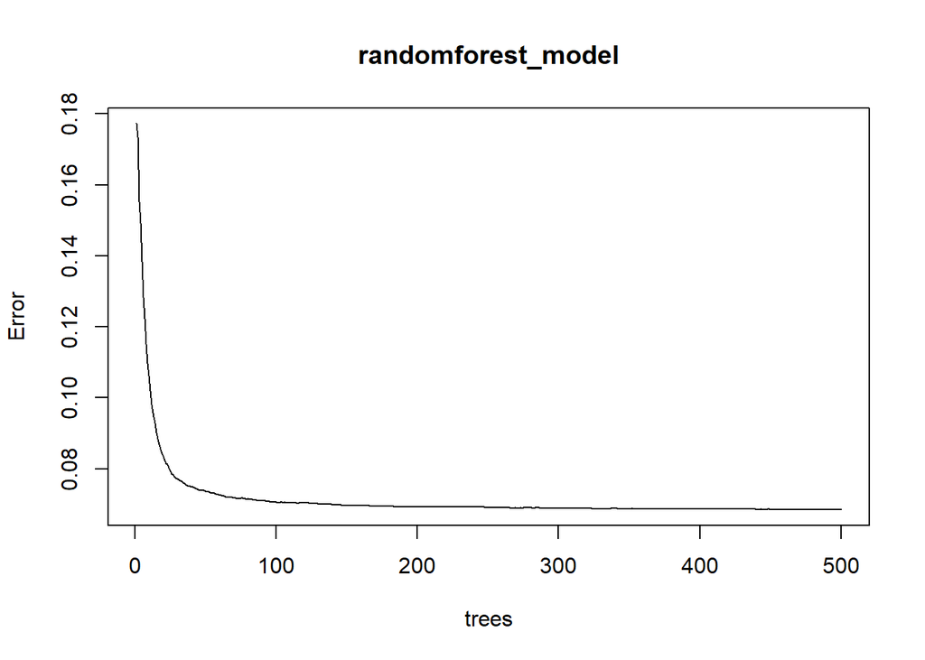

```r
plot(randomforest_model)
```

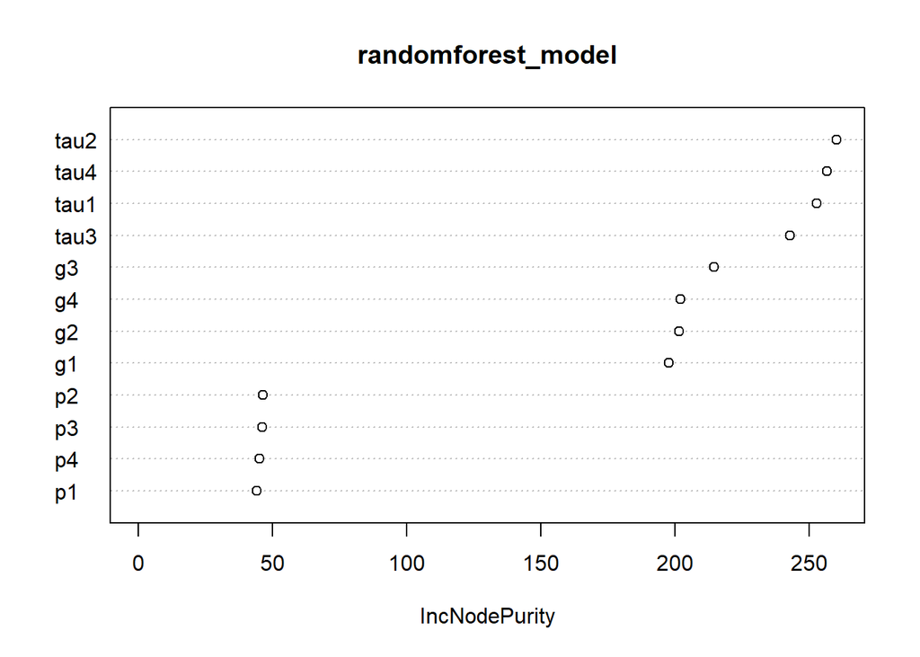

```r
varImpPlot(randomforest_model)
```

```r
importance(randomforest_model)
```

```
##      IncNodePurity
## tau1     252.78474
## tau2     260.21232
## tau3     242.79918
## tau4     256.63050
## p1        44.16594
## p2        46.31126
## p3        46.25374
## p4        45.00016
## g1       197.76462
## g2       201.44270
## g3       214.54893
## g4       202.01124
```

Some variables are less important compared to others like p2, p3, p4, p1…

## Predictions

```r
pred = predict(randomforest_model, newdata = my_data_test, type ="response")
pred.randf_improved_stab = ifelse(pred >= 0.5, "stable", "unstable")
```

## Write csv

```r
to_be_submitted = data.frame(id=rownames(my_data_test), target=pred.randf_improved_stab)
write.csv(to_be_submitted , file = "randForestImprovedModel.csv", row.names = F)
```

# Boosting Tree

Here is our best model which gave us 0,93600, using the gbm technic : boosted regression models

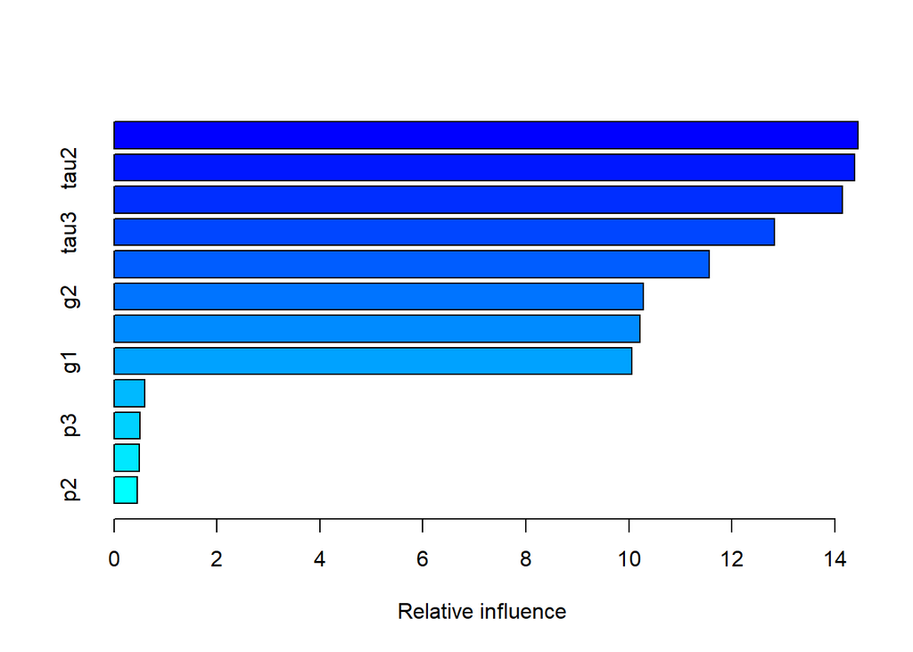

```
##       var    rel.inf
## tau4 tau4 14.4527135
## tau2 tau2 14.3860700
## tau1 tau1 14.1565619
## tau3 tau3 12.8356858
## g3     g3 11.5602011
## g2     g2 10.2895923
## g4     g4 10.2168890
## g1     g1 10.0605032
## p1     p1  0.5960087
## p3     p3  0.4976231
## p4     p4  0.4922138
## p2     p2  0.4559378
```

```r
library(gbm)
hackathon_boost = gbm(stab ~ ., data = my_data_train, distribution = "gaussian", n.trees = 5000, interaction.depth = 4, shrinkage = 0.005)
summary(hackathon_boost)
```

We have improved several times this model by changing the values of interaction.depth and shrinkage… (First we try shrinkage=0.01 => shrinkage=0.005 => shrinkage=0.001) Best was for shrinkage=0.005.

Interaction.depth manages the number of leaves for the three : NumberOfLeaves = interaction.depth + 1 (First we try 3 => 4 => 5 => 6) Best was for Interaction.depth=4.

Shrinkage defines the steps taken in the gradient descent of boosting, as boosting will do a convergence toward Y taking an optimisation view. Higher steeps mean you will converge faster, with the danger missing the optimum point. In Gbm, you have to balance shrinkage with iterations.

## Predictions

```r
pred = predict(hackathon_boost, newdata = my_data_test, type ="response")
```

```
## Using 5000 trees...
```

```r
pred.boost = ifelse(pred >= 0.5, "stable", "unstable")
```

## Write the predicted values to a csv file

```r
to_be_submitted = data.frame(id=rownames(my_data_test), target=pred.boost)
write.csv(to_be_submitted , file = "boostingModel5.csv", row.names = F)
```